# Script to validate points in ReSurvey database using RS data (S2 + SatEmb + Landsat)

Fitting Random Forest models with ntree = 1500, excluding manipulated observations

Alicia Valdés

27 enero 2026

This R script is used to validate the points in the ReSurvey database using either RS indicators from S2 or Landsat (indices + phenology + canopy height), or bands from the Google Satellite Embedding dataset: https://developers.google.com/earth-engine/datasets/catalog/GOOGLE_SATELLITE_EMBEDDING_V1_ANNUAL#description Here, we filter out manipulated observations to avoid using them in analyses.

# Load libraries

```r
library(tidyverse)
library(here)
library(parallel)
library(doParallel)
library(moreparty)
library(caret)
library(randomForest)
library(pROC)
library(rlang)
library(stringr)
library(beepr)
library(permimp)
library(purrr)
```

# Load functions

```r
knitr::purl("functions_20260122.Rmd", output = "functions_20260122.R")
```

```
[1] "functions_20260122.R"
```

```r
source("functions_20260122.R")
```

# Load previously created objects

```r
# Define the folder path
folder_path <- here("objects", "RF_1500_20260127")

# List all .RData or .rda files in the folder
rdata_files <- list.files(folder_path, full.names = TRUE)

# Load each file
lapply(rdata_files, load, envir = .GlobalEnv)
```

```
[[1]]
[1] "filtered_data_both_Landsat_with_probs"

[[2]]
[1] "filtered_data_both_S2_with_probs"

[[3]]
[1] "filtered_data_months_Landsat_with_probs"

[[4]]
[1] "filtered_data_months_S2_with_probs"

[[5]]
[1] "filtered_data_SatEmb_CH_with_probs"

[[6]]
[1] "filtered_data_SatEmb_with_probs"

[[7]]
[1] "filtered_data_slope_Landsat_with_probs"

[[8]]
[1] "filtered_data_slope_S2_with_probs"

[[9]]
[1] "rf_both_Landsat"

[[10]]
[1] "rf_both_Landsat_prediction"

[[11]]
[1] "rf_both_Landsat_roc_data"

[[12]]
[1] "rf_both_Landsat_varimp"

[[13]]
[1] "rf_both_S2"

[[14]]
```

[output cut: 64 more lines]

```

[[36]]
[1] "rf_slope_Landsat_varimp"

[[37]]
[1] "rf_slope_S2"

[[38]]
[1] "rf_slope_S2_prediction"

[[39]]
[1] "rf_slope_S2_roc_data"

[[40]]
[1] "rf_slope_S2_varimp"
```

# Read data

```r
data_validation_S2 <- read_tsv(here(
  "data", "clean","final_RS_data_bands_S2_all_20251021.csv"))
data_validation_SatEmb <- read_tsv(here(
  "data", "clean","final_RS_data_SatEmb_20251010.csv")) %>%
  rename(EUNISa_1_descr = EUNIS_1_d)
data_validation_Landsat <- read_tsv(here(
  "data", "clean","final_RS_data_bands_Landsat_all_20251021.csv"))
```

No parsing issues!

```r
nrow(data_validation_S2)
```

```
[1] 36552
```

```r
nrow(data_validation_Landsat)
```

```
[1] 175039
```

```r
nrow(data_validation_SatEmb)
```

```
[1] 36552
```

# Filter out manipulated observations

## Read list of PlotObservationIDs to keep

```r
PlotObservationID_list <- read_csv(
  here("data", "clean","PlotObservationIDs_filtered_QRST_20260122.csv"))
```

## Filter out data to keep only those PlotObservationIDs

```r
data_validation_S2 <- data_validation_S2 %>%
  filter(PlotObservationID %in% PlotObservationID_list$PlotObservationID)
data_validation_SatEmb <- data_validation_SatEmb %>%
  filter(PlotObservationID %in% PlotObservationID_list$PlotObservationID)
data_validation_Landsat <- data_validation_Landsat %>%
  filter(PlotObservationID %in% PlotObservationID_list$PlotObservationID)
```

```r
nrow(data_validation_S2)
```

```
[1] 31359
```

```r
nrow(data_validation_Landsat)
```

```
[1] 148130
```

```r
nrow(data_validation_SatEmb)
```

```
[1] 31359
```

# Descriptives

Number of observations with S2 data:

```r
data_validation_S2 %>%
  filter(if_any(c(2:86, 91:132), ~ !is.na(.))) %>%
  nrow()
```

```
[1] 31308
```

Number of observations with Landsat data:

```r
data_validation_Landsat %>%
  filter(if_any(c(2:86, 91:132), ~ !is.na(.))) %>%
  nrow()
```

```
[1] 103316
```

Number of observations with SatEmb data:

```r
data_validation_SatEmb %>%
  filter(if_any(c(2:65), ~ !is.na(.))) %>%
  nrow()
```

```
[1] 31359
```

# Define lists of predictor vars

## S2 and Landsat

### Moments with slope method

Not using threshold method cause it gave worse results earlier.

```r
vars_RF_slope <- c(
  # Min values of all indices
  "NDVI_min", "EVI_min", "NDMI_min", "NDWI_min", "SAVI_min",
  # Max values of NDMI and NDWI
  "NDMI_max", "NDWI_max",
  # AUC of NDVI, EVI and SAVI
  "NDVI_auc_slope", "EVI_auc_slope", "SAVI_auc_slope",
  # Values of NDVI, EVI and SAVI at sos, pos and eos
  "NDVI_sos_slope_value", "NDVI_pos_value", "NDVI_eos_slope_value",
  "EVI_sos_slope_value", "EVI_pos_value", "EVI_eos_slope_value",
  "SAVI_sos_slope_value", "SAVI_pos_value", "SAVI_eos_slope_value",
  # Differences pos-sos in value and doy
  "NDVI_diff_pos_sos_slope_value", "EVI_diff_pos_sos_slope_value",
  "SAVI_diff_pos_sos_slope_value","NDVI_diff_pos_sos_slope_doy",
  "EVI_diff_pos_sos_slope_doy", "SAVI_diff_pos_sos_slope_doy",
  # Differences pos-eos in value and doy
  "NDVI_diff_pos_eos_slope_value", "EVI_diff_pos_eos_slope_value",
  "SAVI_diff_pos_eos_slope_value", "NDVI_diff_pos_eos_slope_doy",
  "EVI_diff_pos_eos_slope_doy", "SAVI_diff_pos_eos_slope_doy",
  # Growing season duration
  "NDVI_slope_gsd", "EVI_slope_gsd", "SAVI_slope_gsd",
  # Canopy height
  "canopy_height")
```

```r
# Excluding EVI because many values outside of range -1, 1
vars_RF_slope_Landsat <- c(
  # Min values of all indices
  "NDVI_min", "NDMI_min", "NDWI_min", "SAVI_min",
  # Max values of NDMI and NDWI
  "NDMI_max", "NDWI_max",
  # AUC of NDVI and SAVI
  "NDVI_auc_slope", "SAVI_auc_slope",
  # Values of NDVI and SAVI at sos, pos and eos
  "NDVI_sos_slope_value", "NDVI_pos_value", "NDVI_eos_slope_value",
  "SAVI_sos_slope_value", "SAVI_pos_value", "SAVI_eos_slope_value",
  # Differences pos-sos in value and doy
  "NDVI_diff_pos_sos_slope_value","SAVI_diff_pos_sos_slope_value",
  "NDVI_diff_pos_sos_slope_doy", "SAVI_diff_pos_sos_slope_doy",
  # Differences pos-eos in value and doy
  "NDVI_diff_pos_eos_slope_value", "SAVI_diff_pos_eos_slope_value",
  "NDVI_diff_pos_eos_slope_doy", "SAVI_diff_pos_eos_slope_doy",
  # Growing season duration
  "NDVI_slope_gsd", "SAVI_slope_gsd",
  # Canopy height
  "canopy_height")
```

### Months method

```r
vars_RF_months <- c(
  # Min values of all indices
  "NDVI_min", "EVI_min", "NDMI_min", "NDWI_min", "SAVI_min",
  # Max values of NDMI and NDWI
  "NDMI_max", "NDWI_max",
  # AUC of NDVI, EVI and SAVI between march and oct
  "NDVI_auc_mar_oct", "EVI_auc_mar_oct", "SAVI_auc_mar_oct",
  # Values of NDVI, EVI and SAVI at march, pos and oct
  "NDVI_avg_value_03", "NDVI_pos_value", "NDVI_avg_value_10",
  "EVI_avg_value_03", "EVI_pos_value", "EVI_avg_value_10",
  "SAVI_avg_value_03", "SAVI_pos_value", "SAVI_avg_value_10",
  # Differences pos-march in value and doy
  "NDVI_diff_pos_march_value", "EVI_diff_pos_march_value",
  "SAVI_diff_pos_march_value","NDVI_diff_pos_march_doy",
  "EVI_diff_pos_march_doy", "SAVI_diff_pos_march_doy",
  # Differences pos-oct in value and doy
  "NDVI_diff_pos_oct_value", "EVI_diff_pos_oct_value",
  "SAVI_diff_pos_oct_value", "NDVI_diff_pos_oct_doy",
  "EVI_diff_pos_oct_doy", "SAVI_diff_pos_oct_doy",
  # Canopy height
  "canopy_height")
```

```r
# Excluding EVI because many values outside of range -1, 1
vars_RF_months_Landsat <- c(
  # Min values of all indices
  "NDVI_min", "NDMI_min", "NDWI_min", "SAVI_min",
  # Max values of NDMI and NDWI
  "NDMI_max", "NDWI_max",
  # AUC of NDVI, and SAVI between march and oct
  "NDVI_auc_mar_oct", "SAVI_auc_mar_oct",
  # Values of NDVI and SAVI at march, pos and oct
  "NDVI_avg_value_03", "NDVI_pos_value", "NDVI_avg_value_10",
  "SAVI_avg_value_03", "SAVI_pos_value", "SAVI_avg_value_10",
  # Differences pos-march in value and doy
  "NDVI_diff_pos_march_value", "SAVI_diff_pos_march_value",
  "NDVI_diff_pos_march_doy", "SAVI_diff_pos_march_doy",
  # Differences pos-oct in value and doy
  "NDVI_diff_pos_oct_value", "SAVI_diff_pos_oct_value",
  "NDVI_diff_pos_oct_doy", "SAVI_diff_pos_oct_doy",
  # Canopy height
  "canopy_height")
```

### Both

Slope + months (Borja’s suggestion).

```r
vars_RF_both <- c(
  # Min values of all indices
  "NDVI_min", "EVI_min", "NDMI_min", "NDWI_min", "SAVI_min",
  # Max values of NDMI and NDWI
  "NDMI_max", "NDWI_max",
  # AUC of NDVI, EVI and SAVI
  "NDVI_auc_slope", "EVI_auc_slope", "SAVI_auc_slope",
  # AUC of NDVI, EVI and SAVI between march and oct
  "NDVI_auc_mar_oct", "EVI_auc_mar_oct", "SAVI_auc_mar_oct",
  # Values of NDVI, EVI and SAVI at sos, pos and eos
  "NDVI_sos_slope_value", "NDVI_pos_value", "NDVI_eos_slope_value",
  "EVI_sos_slope_value", "EVI_pos_value", "EVI_eos_slope_value",
  "SAVI_sos_slope_value", "SAVI_pos_value", "SAVI_eos_slope_value",
  # Differences pos-sos in value and doy
  "NDVI_diff_pos_sos_slope_value", "EVI_diff_pos_sos_slope_value",
  "SAVI_diff_pos_sos_slope_value","NDVI_diff_pos_sos_slope_doy",
  "EVI_diff_pos_sos_slope_doy", "SAVI_diff_pos_sos_slope_doy",
  # Differences pos-eos in value and doy
  "NDVI_diff_pos_eos_slope_value", "EVI_diff_pos_eos_slope_value",
  "SAVI_diff_pos_eos_slope_value", "NDVI_diff_pos_eos_slope_doy",
  "EVI_diff_pos_eos_slope_doy", "SAVI_diff_pos_eos_slope_doy",
  # Growing season duration
  "NDVI_slope_gsd", "EVI_slope_gsd", "SAVI_slope_gsd",
  # Values of NDVI, EVI and SAVI at march and oct
  "NDVI_avg_value_03", "NDVI_avg_value_10",
  "EVI_avg_value_03", "EVI_avg_value_10",
  "SAVI_avg_value_03", "SAVI_avg_value_10",
  # Differences pos-march in value and doy
  "NDVI_diff_pos_march_value", "EVI_diff_pos_march_value",
  "SAVI_diff_pos_march_value","NDVI_diff_pos_march_doy",
  "EVI_diff_pos_march_doy", "SAVI_diff_pos_march_doy",
  # Differences pos-oct in value and doy
  "NDVI_diff_pos_oct_value", "EVI_diff_pos_oct_value",
  "SAVI_diff_pos_oct_value", "NDVI_diff_pos_oct_doy",
  "EVI_diff_pos_oct_doy", "SAVI_diff_pos_oct_doy",
  # Canopy height
  "canopy_height")
```

```r
# Excluding EVI because many values outside of range -1, 1
vars_RF_both_Landsat <- c(
  # Min values of all indices
  "NDVI_min", "NDMI_min", "NDWI_min", "SAVI_min",
  # Max values of NDMI and NDWI
  "NDMI_max", "NDWI_max",
  # AUC of NDVI and SAVI
  "NDVI_auc_slope", "SAVI_auc_slope",
  # AUC of NDVI, and SAVI between march and oct
  "NDVI_auc_mar_oct", "SAVI_auc_mar_oct",
  # Values of NDVI and SAVI at sos, pos and eos
  "NDVI_sos_slope_value", "NDVI_pos_value", "NDVI_eos_slope_value",
  "SAVI_sos_slope_value", "SAVI_pos_value", "SAVI_eos_slope_value",
  # Differences pos-sos in value and doy
  "NDVI_diff_pos_sos_slope_value","SAVI_diff_pos_sos_slope_value",
  "NDVI_diff_pos_sos_slope_doy", "SAVI_diff_pos_sos_slope_doy",
  # Differences pos-eos in value and doy
  "NDVI_diff_pos_eos_slope_value", "SAVI_diff_pos_eos_slope_value",
  "NDVI_diff_pos_eos_slope_doy", "SAVI_diff_pos_eos_slope_doy",
  # Growing season duration
  "NDVI_slope_gsd", "SAVI_slope_gsd",
  # Values of NDVI and SAVI at march and oct
  "NDVI_avg_value_03", "NDVI_avg_value_10",
  "SAVI_avg_value_03", "SAVI_avg_value_10",
  # Differences pos-march in value and doy
  "NDVI_diff_pos_march_value", "SAVI_diff_pos_march_value",
  "NDVI_diff_pos_march_doy", "SAVI_diff_pos_march_doy",
  # Differences pos-oct in value and doy
  "NDVI_diff_pos_oct_value", "SAVI_diff_pos_oct_value",
  "NDVI_diff_pos_oct_doy", "SAVI_diff_pos_oct_doy",
  # Canopy height
  "canopy_height")
```

## SatEmb

```r
vars_RF_SatEmb <- colnames(
  data_validation_SatEmb)[startsWith(colnames(data_validation_SatEmb), "A")]
vars_RF_SatEmb_CH <- c(vars_RF_SatEmb, "canopy_height")
```

# Filter data to use in RF models

## Functions

```r
filter_data_S2 <- function(data, variables) {
  data %>%
    mutate(EUNISa_1 = as.factor(EUNISa_1)) %>%
    # Remove rows with missing values in predictors
    dplyr::filter(if_all(all_of(variables), ~ !is.na(.))) %>%
    # Remove all rows with wrong values of indices (not between -1 and 1)
    dplyr::filter(NDVI_max <= 1 & NDVI_min >= -1) %>%
    dplyr::filter(EVI_max <= 1 & EVI_min >= -1) %>%
    dplyr::filter(SAVI_max <= 1 & SAVI_min >= -1) %>%
    dplyr::filter(NDMI_max <= 1 & NDMI_min >= -1) %>%
    dplyr::filter(NDWI_max <= 1 & NDWI_min >= -1) %>%
    # Select only variables needed
    dplyr::select(PlotObservationID, EUNISa_1, all_of(variables), Lctnmth,
           valid_1) %>%
    # Keep only rows with differences > 0 in variables
    filter(if_all(any_of(variables[grepl("diff", variables)]),
                  ~ .x > 0)) %>%
    # Select only GPS points
    dplyr::filter(Lctnmth == "Location with GPS" |
                    Lctnmth == "Location with differential GPS")
}
```

```r
filter_data_Landsat <- function(data, variables) {
  data %>%
    mutate(EUNISa_1 = as.factor(EUNISa_1)) %>%
    # Remove rows with missing values in predictors
    dplyr::filter(if_all(all_of(variables), ~ !is.na(.))) %>%
    # Remove all rows with wrong values of indices (not between -1 and 1)
    dplyr::filter(NDVI_max <= 1 & NDVI_min >= -1) %>%
    # With Landsat data, many observations removed because of high/low EVI values
    # In Landsat_extraction, values of EVI outside of expected range were set as NA,
    # so better not to use EVI here
    # dplyr::filter(EVI_max <= 1 & EVI_min >= -1) %>%
    dplyr::filter(SAVI_max <= 1 & SAVI_min >= -1) %>%
    dplyr::filter(NDMI_max <= 1 & NDMI_min >= -1) %>%
    dplyr::filter(NDWI_max <= 1 & NDWI_min >= -1) %>%
    # Select only variables needed
    dplyr::select(PlotObservationID, EUNISa_1, all_of(variables), Lctnmth,
           valid_1) %>%
    # Keep only rows with differences > 0 in variables
    filter(if_all(any_of(variables[grepl("diff", variables)]),
                  ~ .x > 0)) %>%
    # Select only GPS points
    dplyr::filter(Lctnmth == "Location with GPS" |
                    Lctnmth == "Location with differential GPS")
}
```

```r
filter_data_SatEmb <- function(data, variables) {
  data %>%
    mutate(EUNISa_1 = as.factor(EUNISa_1)) %>%
    # Remove rows with missing values in predictors
    dplyr::filter(if_all(all_of(variables), ~ !is.na(.))) %>%
    # Select only variables needed
    dplyr::select(PlotObservationID, EUNISa_1, all_of(variables),
           Lctnmth, valid_1) %>%
    # Select only GPS points
    dplyr::filter(Lctnmth == "Location with GPS" |
                    Lctnmth == "Location with differential GPS")
  }
```

## Filtered data

Select only GPS points that have passed the rough validation in each case.

For S2 and Landsat, use only slope and months methods, as threshold method has many missing values.

```r
# S2
filtered_data_slope_S2 <- filter_data_S2(
  data_validation_S2 %>%
    rough_validation_S2(), # Rough validation based on CH and NDWI
  vars_RF_slope)
filtered_data_months_S2 <- filter_data_S2(
  data_validation_S2 %>%
    rough_validation_S2(), # Rough validation based on CH and NDWI
  vars_RF_months)
filtered_data_both_S2 <- filter_data_S2(
  data_validation_S2 %>%
    rough_validation_S2(), # Rough validation based on CH and NDWI
  vars_RF_both)

# Landsat
filtered_data_slope_Landsat <- filter_data_Landsat(
  data_validation_Landsat %>%
    rough_validation_Landsat(), # Rough validation based on NDWI
  vars_RF_slope_Landsat)
filtered_data_months_Landsat <- filter_data_Landsat(
  data_validation_Landsat %>%
    rough_validation_Landsat(), # Rough validation based on NDWI
  vars_RF_months_Landsat)
filtered_data_both_Landsat <- filter_data_Landsat(
  data_validation_Landsat %>%
    rough_validation_Landsat(), # Rough validation based on CH and NDWI
  vars_RF_both_Landsat)

# SatEmb
filtered_data_SatEmb <- filter_data_SatEmb(
  data_validation_SatEmb %>%
    rough_validation_SatEmb(), # Rough validation based on CH
  vars_RF_SatEmb)
filtered_data_SatEmb_CH <- filter_data_SatEmb(
  data_validation_SatEmb %>%
    rough_validation_SatEmb(), # Rough validation based on CH
  vars_RF_SatEmb_CH)
```

# Fit RF models (level 1)

## Without refinement

### N points per category

```r
bind_rows(
  # S2
  filtered_data_slope_S2 %>% count(EUNISa_1) %>%
    pivot_wider(names_from = EUNISa_1, values_from = n) %>%
    mutate(sensor = "S2", method = "slope") %>%
    select(sensor, method, Q, R, S, T),
  filtered_data_months_S2 %>% count(EUNISa_1) %>%
    pivot_wider(names_from = EUNISa_1, values_from = n) %>%
    mutate(sensor = "S2", method = "months") %>%
    select(sensor, method, Q, R, S, T),
  filtered_data_both_S2 %>% count(EUNISa_1) %>%
    pivot_wider(names_from = EUNISa_1, values_from = n) %>%
    mutate(sensor = "S2", method = "both") %>%
    select(sensor, method, Q, R, S, T),
  # # Landsat
  filtered_data_slope_Landsat %>% count(EUNISa_1) %>%
    pivot_wider(names_from = EUNISa_1, values_from = n) %>%
    mutate(sensor = "Landsat", method = "slope") %>%
    select(sensor, method, Q, R, S, T),
  filtered_data_months_Landsat %>% count(EUNISa_1) %>%
    pivot_wider(names_from = EUNISa_1, values_from = n) %>%
    mutate(sensor = "Landsat", method = "months") %>%
    select(sensor, method, Q, R, S, T),
  filtered_data_both_Landsat %>% count(EUNISa_1) %>%
    pivot_wider(names_from = EUNISa_1, values_from = n) %>%
    mutate(sensor = "Landsat", method = "both") %>%
    select(sensor, method, Q, R, S, T),
  # SatEmb
  filtered_data_SatEmb %>% count(EUNISa_1) %>%
    pivot_wider(names_from = EUNISa_1, values_from = n) %>%
    mutate(sensor = "SatEmb", method ="SatEmb only") %>%
    select(sensor, method, Q, R, S, T),
  filtered_data_SatEmb_CH %>% count(EUNISa_1) %>%
    pivot_wider(names_from = EUNISa_1, values_from = n) %>%
    mutate(sensor = "SatEmb", method ="SatEmb + CH") %>%
    select(sensor, method, Q, R, S, T)
)
```

| sensor | method | Q | R | S | T |
| --- | --- | --- | --- | --- | --- |
| S2 | slope | 6159 | 11202 | 4290 | 765 |
| S2 | months | 5199 | 9631 | 3738 | 771 |
| S2 | both | 5130 | 9517 | 3682 | 722 |
| Landsat | slope | 18775 | 33807 | 12310 | 2071 |
| Landsat | months | 11487 | 20621 | 7357 | 1306 |
| Landsat | both | 11187 | 20166 | 7160 | 1302 |
| SatEmb | SatEmb only | 6387 | 12459 | 4434 | 823 |
| SatEmb | SatEmb + CH | 6387 | 12459 | 4434 | 823 |

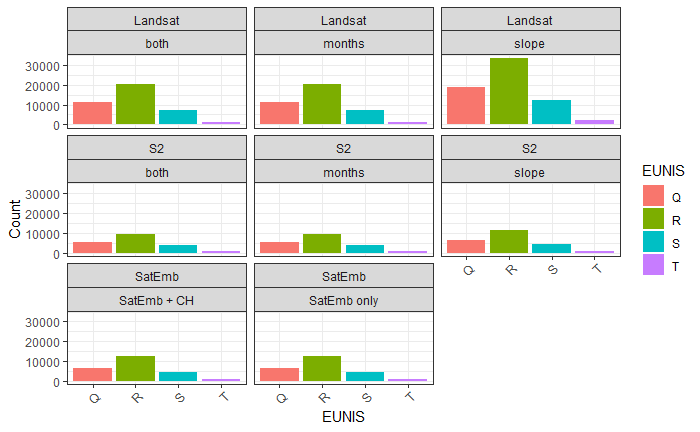

```r
bind_rows(
  # S2
  filtered_data_slope_S2 %>% count(EUNISa_1) %>%
    pivot_wider(names_from = EUNISa_1, values_from = n) %>%
    mutate(sensor = "S2", method = "slope") %>%
    select(sensor, method, Q, R, S, T),
  filtered_data_months_S2 %>% count(EUNISa_1) %>%
    pivot_wider(names_from = EUNISa_1, values_from = n) %>%
    mutate(sensor = "S2", method = "months") %>%
    select(sensor, method, Q, R, S, T),
  filtered_data_both_S2 %>% count(EUNISa_1) %>%
    pivot_wider(names_from = EUNISa_1, values_from = n) %>%
    mutate(sensor = "S2", method = "both") %>%
    select(sensor, method, Q, R, S, T),
  # # Landsat
  filtered_data_slope_Landsat %>% count(EUNISa_1) %>%
    pivot_wider(names_from = EUNISa_1, values_from = n) %>%
    mutate(sensor = "Landsat", method = "slope") %>%
    select(sensor, method, Q, R, S, T),
  filtered_data_months_Landsat %>% count(EUNISa_1) %>%
    pivot_wider(names_from = EUNISa_1, values_from = n) %>%
    mutate(sensor = "Landsat", method = "months") %>%
    select(sensor, method, Q, R, S, T),
  filtered_data_both_Landsat %>% count(EUNISa_1) %>%
    pivot_wider(names_from = EUNISa_1, values_from = n) %>%
    mutate(sensor = "Landsat", method = "both") %>%
    select(sensor, method, Q, R, S, T),
  # SatEmb
  filtered_data_SatEmb %>% count(EUNISa_1) %>%
    pivot_wider(names_from = EUNISa_1, values_from = n) %>%
    mutate(sensor = "SatEmb", method ="SatEmb only") %>%
    select(sensor, method, Q, R, S, T),
  filtered_data_SatEmb_CH %>% count(EUNISa_1) %>%
    pivot_wider(names_from = EUNISa_1, values_from = n) %>%
    mutate(sensor = "SatEmb", method ="SatEmb + CH") %>%
    select(sensor, method, Q, R, S, T)
) %>%
  pivot_longer(cols = 3:6, names_to = "EUNIS", values_to = "Count") %>%
  ggplot(aes(x = EUNIS, y = Count, fill = EUNIS, group = EUNIS)) +
  geom_col() +
  facet_wrap(~ sensor + method) + theme_bw() +
  # ggtitle("Reduction in number of observations with filtering steps") +
  theme(axis.text.x = element_text(angle = 45, hjust = 1))
```

### Split into training and test data sets

Split data:

```r
# S2
# Slope
set.seed(123)
split_data_slope_S2 <- split_train_test(filtered_data_slope_S2)

train_data_slope_S2 <- split_data_slope_S2$train
test_data_slope_S2 <- split_data_slope_S2$test

# Check overlap between training and testing datasets
sum(train_data_slope_S2$PlotObservationID %in% test_data_slope_S2$PlotObservationID)
```

```
[1] 0
```

```r
# Months
set.seed(123)
split_data_months_S2 <- split_train_test(filtered_data_months_S2)

train_data_months_S2 <- split_data_months_S2$train
test_data_months_S2 <- split_data_months_S2$test

# Check overlap between training and testing datasets
sum(train_data_months_S2$PlotObservationID %in% test_data_months_S2$PlotObservationID)
```

```
[1] 0
```

```r
# Both
set.seed(123)
split_data_both_S2 <- split_train_test(filtered_data_both_S2)

train_data_both_S2 <- split_data_both_S2$train
test_data_both_S2 <- split_data_both_S2$test

# Check overlap between training and testing datasets
sum(train_data_both_S2$PlotObservationID %in% test_data_both_S2$PlotObservationID)
```

```
[1] 0
```

```r
# Landsat
# Slope
set.seed(123)
split_data_slope_Landsat <- split_train_test(filtered_data_slope_Landsat)

train_data_slope_Landsat <- split_data_slope_Landsat$train
test_data_slope_Landsat <- split_data_slope_Landsat$test

# Check overlap between training and testing datasets
sum(train_data_slope_Landsat$PlotObservationID %in% test_data_slope_Landsat$PlotObservationID)
```

```
[1] 0
```

```r
# Months
set.seed(123)
split_data_months_Landsat <- split_train_test(filtered_data_months_Landsat)

train_data_months_Landsat <- split_data_months_Landsat$train
test_data_months_Landsat <- split_data_months_Landsat$test

# Check overlap between training and testing datasets
sum(train_data_months_Landsat$PlotObservationID %in% test_data_months_Landsat$PlotObservationID)
```

```
[1] 0
```

```r
# Both
set.seed(123)
split_data_both_Landsat <- split_train_test(filtered_data_both_Landsat)

train_data_both_Landsat <- split_data_both_Landsat$train
test_data_both_Landsat <- split_data_both_Landsat$test

# Check overlap between training and testing datasets
sum(train_data_both_Landsat$PlotObservationID %in% test_data_both_Landsat$PlotObservationID)
```

```
[1] 0
```

```r
# SatEmb
set.seed(123)
split_data_SatEmb <- split_train_test(filtered_data_SatEmb)

train_data_SatEmb <- split_data_SatEmb$train
test_data_SatEmb <- split_data_SatEmb$test

# Check overlap between training and testing datasets
sum(train_data_SatEmb$PlotObservationID %in% test_data_SatEmb$PlotObservationID)
```

```
[1] 0
```

```r
# SatEmb_CH
set.seed(123)
split_data_SatEmb_CH <- split_train_test(filtered_data_SatEmb_CH)

train_data_SatEmb_CH <- split_data_SatEmb_CH$train
test_data_SatEmb_CH <- split_data_SatEmb_CH$test

# Check overlap between training and testing datasets
sum(train_data_SatEmb_CH$PlotObservationID %in% test_data_SatEmb_CH$PlotObservationID)
```

```
[1] 0
```

### Fit models

```r
models_no_refin <- c("rf_slope_S2", "rf_months_S2", "rf_both_S2",
                     "rf_slope_Landsat", "rf_months_Landsat", "rf_both_Landsat",
                     "rf_SatEmb", "rf_SatEmb_CH")
```

Print the time:

```r
for (model_name in models_no_refin) {
  obj <- get(model_name)
  cat("Time for", model_name, ":\n")
  print(obj$time)
}
```

```
Time for rf_slope_S2 :
   user  system elapsed
  13.39    3.54  106.39
Time for rf_months_S2 :
   user  system elapsed
  10.05    2.76   62.72
Time for rf_both_S2 :
   user  system elapsed
  14.87    3.78  180.97
Time for rf_slope_Landsat :
   user  system elapsed
  52.24    8.73  436.95
Time for rf_months_Landsat :
   user  system elapsed
  24.01    4.16  168.98
Time for rf_both_Landsat :
   user  system elapsed
  55.75    7.14  234.08
Time for rf_SatEmb :
   user  system elapsed
  52.60    6.69  201.84
Time for rf_SatEmb_CH :
   user  system elapsed
  32.21    6.03  163.94
```

Save:

### Predictions

```r
predictions_no_refin <- c("rf_slope_S2_prediction", "rf_months_S2_prediction",
                          "rf_both_S2_prediction",
                          "rf_slope_Landsat_prediction",
                          "rf_months_Landsat_prediction",
                          "rf_both_Landsat_prediction",
                          "rf_SatEmb_prediction", "rf_SatEmb_CH_prediction")
```

Save:

### Confusion matrices

```r
for (prediction_name in predictions_no_refin) {
  # Derive test data name by replacing "_prediction" with ""
  # and "rf_" with "test_data_"
  test_data_name <- paste0("test_data_", sub("^rf_", "", sub("_prediction$", "",
                                                             prediction_name)))

  # Get prediction and test data
  prediction <- get(prediction_name)
  test_data <- get(test_data_name)

  # Compute confusion matrix
  cat("Confusion Matrix for", sub("_prediction$", "", prediction_name), ":\n")
  print(confusionMatrix(prediction, test_data$EUNISa_1))
  cat("\n")
}
```

```
Confusion Matrix for rf_slope_S2 :
Confusion Matrix and Statistics

          Reference
Prediction    Q    R    S    T
         Q  254  230  191    0
         R 1561 3082 1084    4
         S   18   34   43    0
         T    0    0    1  223

Overall Statistics

               Accuracy : 0.5356
                 95% CI : (0.5236, 0.5476)
    No Information Rate : 0.4975
    P-Value [Acc > NIR] : 2.281e-10

                  Kappa : 0.1475

 Mcnemar's Test P-Value : NA

Statistics by Class:

                     Class: Q Class: R Class: S Class: T
Sensitivity           0.13857   0.9211 0.032600  0.98238
Specificity           0.91394   0.2160 0.990381  0.99985
Pos Pred Value        0.37630   0.5378 0.452632  0.99554
Neg Pred Value        0.73901   0.7344 0.807541  0.99938
Prevalence            0.27257   0.4975 0.196134  0.03375
Detection Rate        0.03777   0.4583 0.006394  0.03316
Detection Prevalence  0.10037   0.8522 0.014126  0.03331
Balanced Accuracy     0.52626   0.5686 0.511491  0.99111

Confusion Matrix for rf_months_S2 :
Confusion Matrix and Statistics

          Reference
Prediction    Q    R    S    T
         Q  336  267  211    0
         R 1163 2512  817    2
```

[output cut: 208 more lines]

```
                  Kappa : 0.2775

 Mcnemar's Test P-Value : NA

Statistics by Class:

                     Class: Q Class: R Class: S Class: T
Sensitivity           0.36089   0.8499  0.12553  0.97899
Specificity           0.83346   0.4508  0.97186  0.99971
Pos Pred Value        0.43348   0.6191  0.51765  0.99149
Neg Pred Value        0.78693   0.7409  0.82209  0.99929
Prevalence            0.26096   0.5122  0.19389  0.03291
Detection Rate        0.09418   0.4353  0.02434  0.03222
Detection Prevalence  0.21726   0.7032  0.04702  0.03250
Balanced Accuracy     0.59717   0.6504  0.54870  0.98935
```

#### Plots

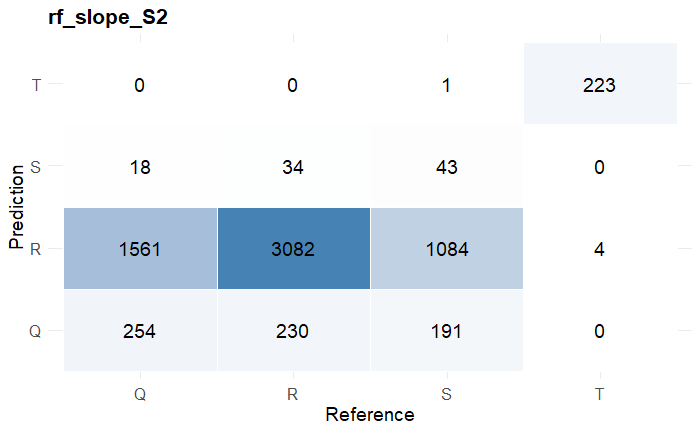

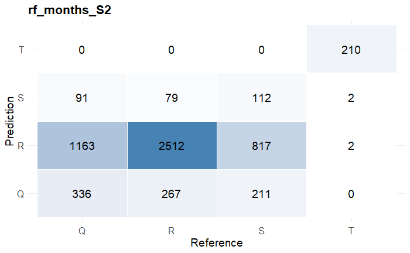

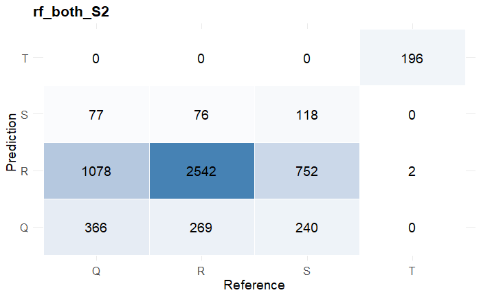

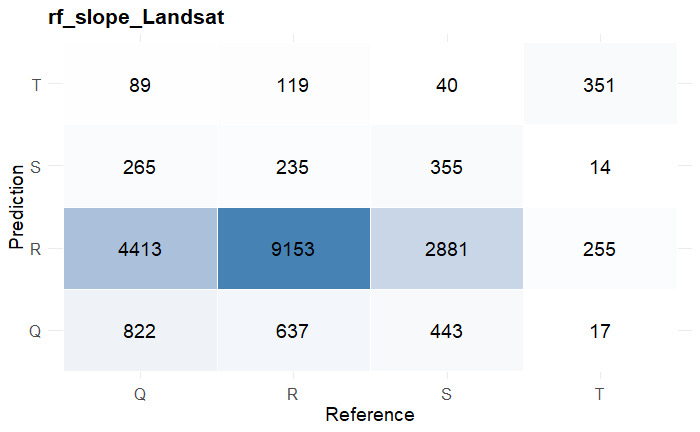

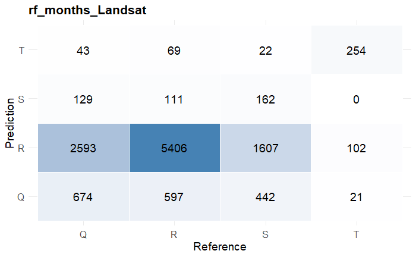

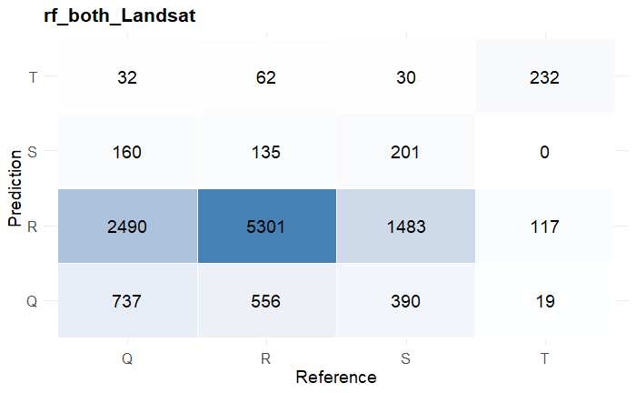

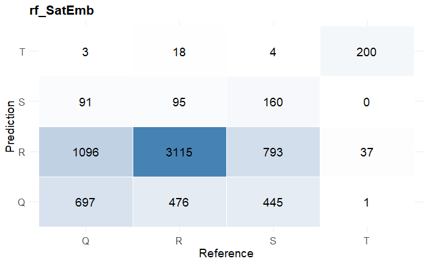

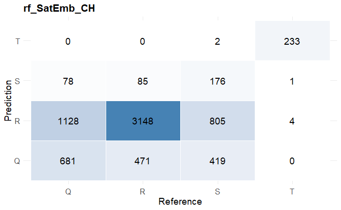

```r
for (prediction_name in predictions_no_refin) {
  # Derive name of test data
  test_data_name <- paste0("test_data_", sub("^rf_", "", sub("_prediction$", "",
                                                             prediction_name)))

  # Obtain objects
  prediction <- get(prediction_name)
  test_data <- get(test_data_name)

  # Personalized title
  title <- paste(#"Confusion Matrix for",
    sub("_prediction$", "",
                                              prediction_name))

  # Plot
  print(plot_confusion_matrix(prediction, test_data$EUNISa_1, title))
}
```

### Variable importance

#### Unconditional

```r
varimp_no_refin <- c("rf_slope_S2_varimp", "rf_months_S2_varimp",
                     "rf_both_S2_varimp",
                     "rf_slope_Landsat_varimp", "rf_months_Landsat_varimp",
                     "rf_both_Landsat_varimp", "rf_SatEmb_varimp",
                     "rf_SatEmb_CH_varimp")
```

Save:

##### Plots

```
Plotting variable importance for rf_slope_S2_varimp ...
Plotting variable importance for rf_months_S2_varimp ...
```

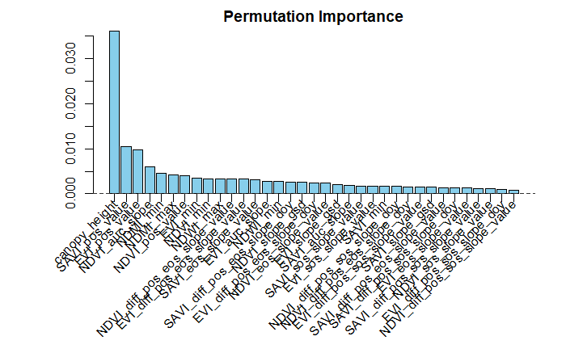

```
Plotting variable importance for rf_both_S2_varimp ...
```

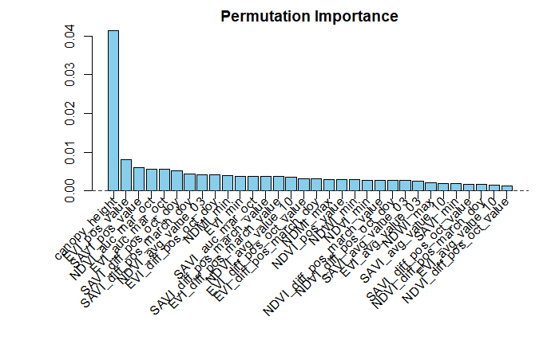

```
Plotting variable importance for rf_slope_Landsat_varimp ...
```

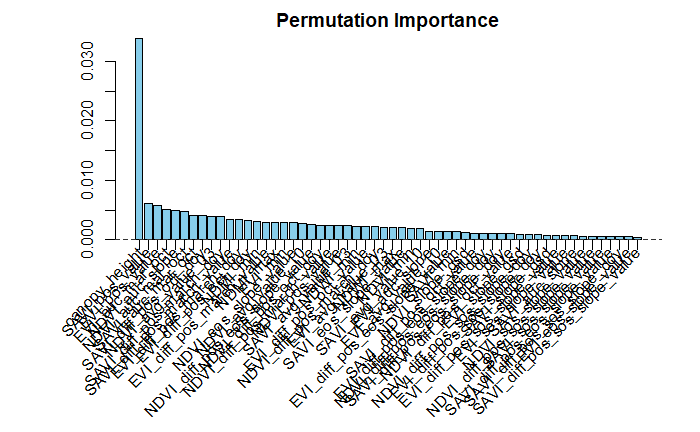

```
Plotting variable importance for rf_months_Landsat_varimp ...
```

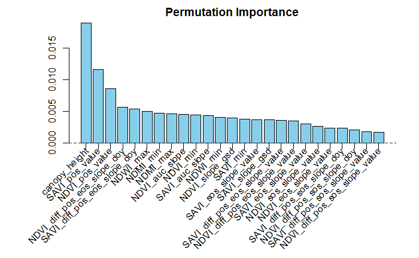

```
Plotting variable importance for rf_both_Landsat_varimp ...
```

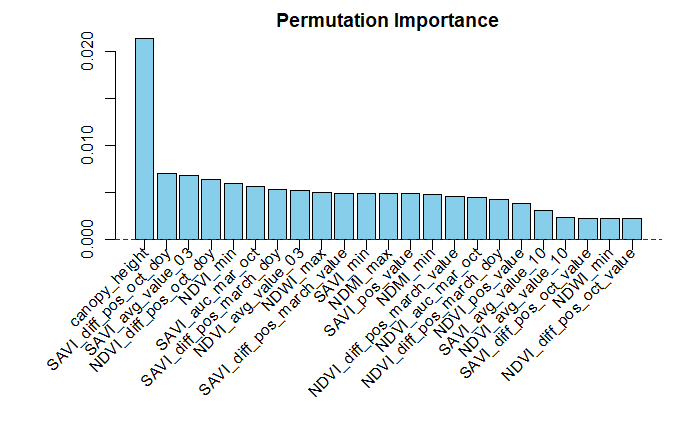

```
Plotting variable importance for rf_SatEmb_varimp ...
```

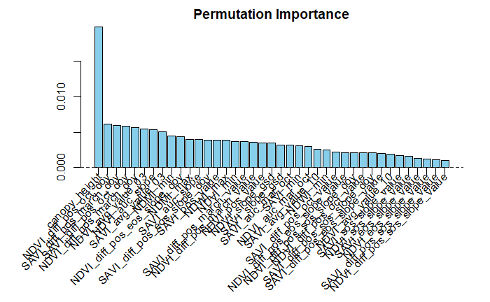

```
Plotting variable importance for rf_SatEmb_CH_varimp ...
```

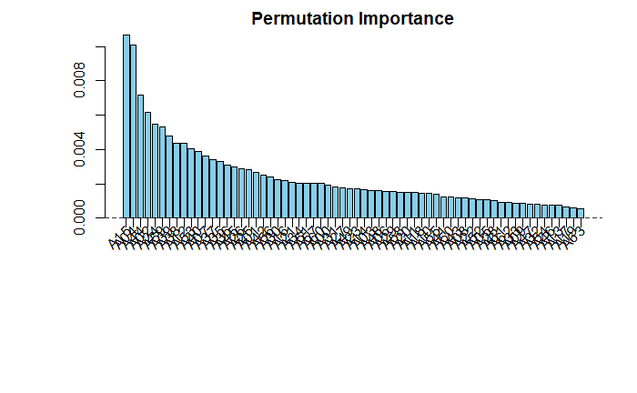

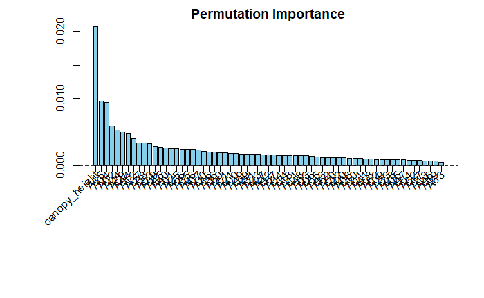

```r
for (varimp_name in varimp_no_refin) {
  cat("Plotting variable importance for", varimp_name, "...\n")
  plot(get(varimp_name)$varimp, margin = c(10, 6, 2, 2))
}
```

#### Conditional (TBD)

### ROC curves

Save:

#### Plots

```r
roc_plots_no_refin <- list()

for (model_name in models_no_refin) {
  roc_data_name <- paste0(model_name, "_roc_data")
  roc_df <- get(roc_data_name)$roc

  roc_plot <- ggplot(roc_df, aes(x = FPR, y = TPR, color = Class)) +
    geom_line(linewidth = 1.2) +
    geom_abline(linetype = "dashed", color = "gray") +
    labs(title = paste("Multiclass ROC Curve -", model_name),
         x = "False Positive Rate",
         y = "True Positive Rate",
         color = "Class (AUC)") +
    theme_minimal() +
    theme(legend.position = "bottom")

  roc_plots_no_refin[[model_name]] <- roc_plot
}
```

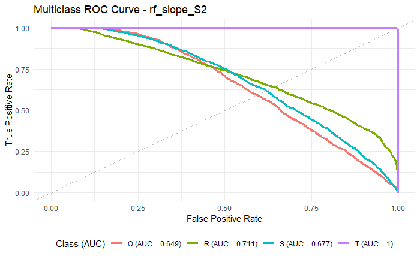

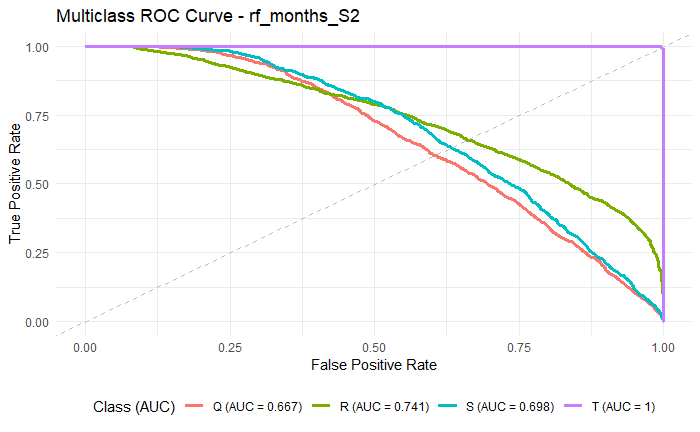

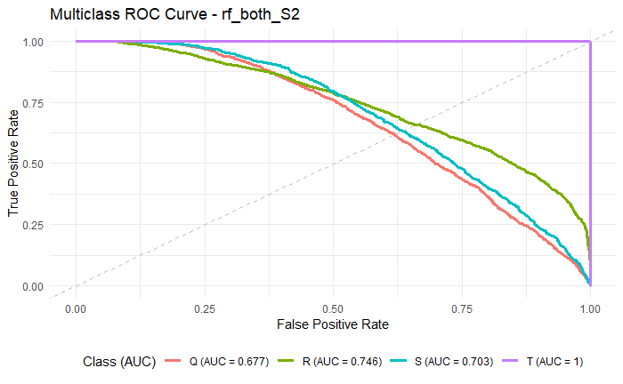

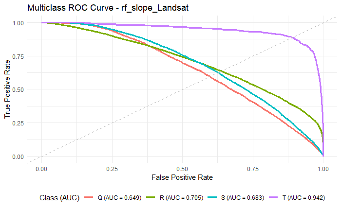

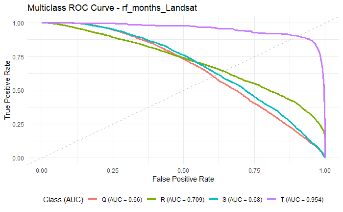

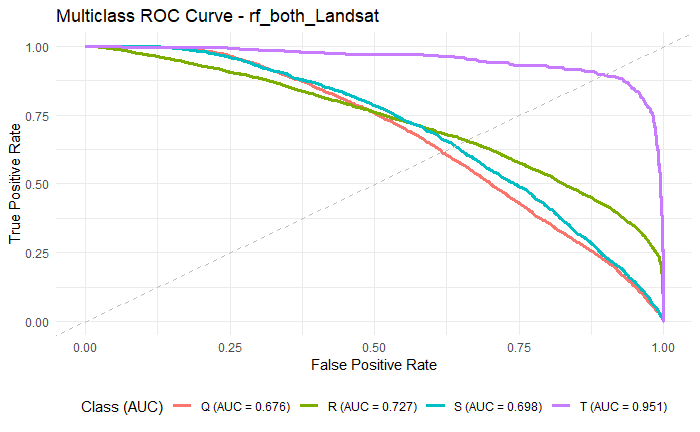

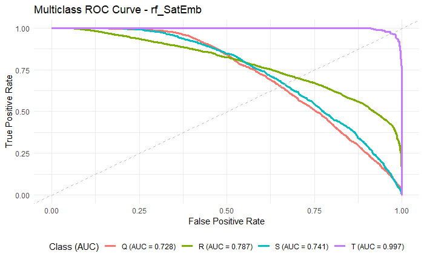

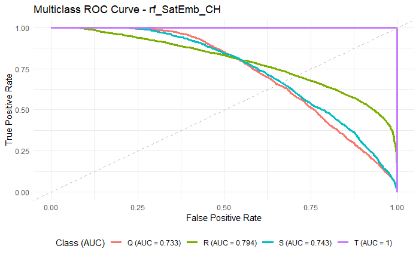

```r
roc_plots_no_refin
```

## Refinement step 1

Based on PAs “Morralla protocol”.

### Compute predictions for all data and combine with original data

```r
filtered_data_with_probs <- c("filtered_data_slope_S2_with_probs",
                              "filtered_data_months_S2_with_probs",
                              "filtered_data_both_S2_with_probs",
                              "filtered_data_slope_Landsat_with_probs",
                              "filtered_data_months_Landsat_with_probs",
                              "filtered_data_both_Landsat_with_probs",
                              "filtered_data_SatEmb_with_probs",
                              "filtered_data_SatEmb_CH_with_probs")
```

Save:

### Detect probability columns

```r
prob_cols_slope_S2 <- names(filtered_data_slope_S2_with_probs)[grepl("^prob_", names(filtered_data_slope_S2_with_probs))]
prob_cols_months_S2 <- names(filtered_data_months_S2_with_probs)[grepl("^prob_", names(filtered_data_months_S2_with_probs))]
prob_cols_both_S2 <- names(filtered_data_both_S2_with_probs)[grepl("^prob_", names(filtered_data_both_S2_with_probs))]
prob_cols_slope_Landsat <- names(filtered_data_slope_Landsat_with_probs)[grepl("^prob_", names(filtered_data_slope_Landsat_with_probs))]
prob_cols_months_Landsat <- names(filtered_data_months_Landsat_with_probs)[grepl("^prob_", names(filtered_data_months_Landsat_with_probs))]
prob_cols_both_Landsat <- names(filtered_data_both_Landsat_with_probs)[grepl("^prob_", names(filtered_data_both_Landsat_with_probs))]
prob_cols_SatEmb <- names(filtered_data_SatEmb_with_probs)[grepl("^prob_", names(filtered_data_SatEmb_with_probs))]
prob_cols_SatEmb_CH <- names(filtered_data_SatEmb_CH_with_probs)[grepl("^prob_", names(filtered_data_SatEmb_CH_with_probs))]
```

### Calculate auxiliary metrics

```r
df_aux_slope_S2 <- calculate_df_aux(filtered_data_slope_S2_with_probs,
                                     prob_cols_slope_S2)
df_aux_months_S2 <- calculate_df_aux(filtered_data_months_S2_with_probs,
                                     prob_cols_months_S2)
df_aux_both_S2 <- calculate_df_aux(filtered_data_both_S2_with_probs,
                                     prob_cols_both_S2)
df_aux_slope_Landsat <- calculate_df_aux(filtered_data_slope_Landsat_with_probs,
                                     prob_cols_slope_Landsat)
df_aux_months_Landsat <- calculate_df_aux(filtered_data_months_Landsat_with_probs,
                                     prob_cols_months_Landsat)
df_aux_both_Landsat <- calculate_df_aux(filtered_data_both_Landsat_with_probs,
                                     prob_cols_both_Landsat)
df_aux_SatEmb <- calculate_df_aux(filtered_data_SatEmb_with_probs,
                                  prob_cols_SatEmb)
df_aux_SatEmb_CH <- calculate_df_aux(filtered_data_SatEmb_CH_with_probs,
                                     prob_cols_SatEmb_CH)
```

### Apply filtering function

Applying “Morralla” protocol once, removing negatives until 20% of the class and, if there is room, uncertain positives until 10% of the rest.

```r
df_final_20_10_slope_S2 <- df_aux_slope_S2 %>%
  group_split(original_EUNIS) %>%
  map_dfr(filter_probs_neg20_pos10)
df_final_20_10_months_S2 <- df_aux_months_S2 %>%
  group_split(original_EUNIS) %>%
  map_dfr(filter_probs_neg20_pos10)
df_final_20_10_both_S2 <- df_aux_both_S2 %>%
  group_split(original_EUNIS) %>%
  map_dfr(filter_probs_neg20_pos10)
df_final_20_10_slope_Landsat <- df_aux_slope_Landsat %>%
  group_split(original_EUNIS) %>%
  map_dfr(filter_probs_neg20_pos10)
df_final_20_10_months_Landsat <- df_aux_months_Landsat %>%
  group_split(original_EUNIS) %>%
  map_dfr(filter_probs_neg20_pos10)
df_final_20_10_both_Landsat <- df_aux_both_Landsat %>%
  group_split(original_EUNIS) %>%
  map_dfr(filter_probs_neg20_pos10)
df_final_20_10_SatEmb <- df_aux_SatEmb %>%
  group_split(original_EUNIS) %>%
  map_dfr(filter_probs_neg20_pos10)
df_final_20_10_SatEmb_CH <- df_aux_SatEmb_CH %>%
  group_split(original_EUNIS) %>%
  map_dfr(filter_probs_neg20_pos10)
```

```r
filtered_data_20_10_slope_S2_probs <- filtered_data_slope_S2 %>%
  dplyr::filter(PlotObservationID %in% df_final_20_10_slope_S2$PlotObservationID)
filtered_data_20_10_months_S2_probs <- filtered_data_months_S2 %>%
  dplyr::filter(PlotObservationID %in% df_final_20_10_months_S2$PlotObservationID)
filtered_data_20_10_both_S2_probs <- filtered_data_both_S2 %>%
  dplyr::filter(PlotObservationID %in% df_final_20_10_both_S2$PlotObservationID)
filtered_data_20_10_slope_Landsat_probs <- filtered_data_slope_Landsat %>%
  dplyr::filter(PlotObservationID %in% df_final_20_10_slope_Landsat$PlotObservationID)
filtered_data_20_10_months_Landsat_probs <- filtered_data_months_Landsat %>%
  dplyr::filter(PlotObservationID %in% df_final_20_10_months_Landsat$PlotObservationID)
filtered_data_20_10_both_Landsat_probs <- filtered_data_both_Landsat %>%
  dplyr::filter(PlotObservationID %in% df_final_20_10_both_Landsat$PlotObservationID)
filtered_data_20_10_SatEmb_probs <- filtered_data_SatEmb %>%
  dplyr::filter(PlotObservationID %in% df_final_20_10_SatEmb$PlotObservationID)
filtered_data_20_10_SatEmb_CH_probs <- filtered_data_SatEmb_CH %>%
  dplyr::filter(PlotObservationID %in% df_final_20_10_SatEmb_CH$PlotObservationID)
```